# API querying and data wrangling in Python

In the present project, I gather, assess, wrangle, and clean a dataset assembled from data from the channel "We rate dogs". I use Twitter API to query the text of the tweets and gather missing columns from the base dataset, and request a dataset with the associated images. I use Python tools to assess any problems with the data. The result is a tidy and useful dataset of good quality data.

The data: Users submit pictures and a short text to the group "We rate dogs", and have the pet rated. Most of the time, dogs are classified into stages known to that specific community: dogo, puppo, pupper. Other comments generally using internal lingo, and the names of the dogs are usually given as well.

Steps in this project:

1 - Gathering the data: load existing dataset, use Twitter API to query tweets, use information extracted in JSON, request the images dataset from a website and save it as a local dataset.

2 - Assess data: assess data sources for "quality" and "tidiness". Issues include, but are not limited to: different sizes of merged datasets, mismatch of text for dog stage between base dataset entry and tweet due to problem capturing string, incorrectly captured dog names, tweets later deleted by users, among others.

3 - Cleaning data: establish and execute an action for each of the quality and tidiness problems found.

4 - Plots and comments: a first approach to analyzing the data with preliminary plots. I found that for this channel, the top five most popular breeds are Golden Retriever, Labrador Retriever, Pembroke, Chihuahua, and Pug, with the top one, Golden Retriever, appearing almost double and three times more than fourth and fifth places.The breeds whose photos and tweet were most retweeted were also, in order, Golden Retriever, Labrador Retriever, Pembroke, Chihuahua, but in fifth place is Samoyed (seventh in number of appearances). Pugs are popular but do not get as retweeted.

```python
import requests
import numpy as np
import pandas as pd
import json
import tweepy
import sys
```

## 1 - Gathering the data

```python
# Load base dataset
tw = pd.read_csv("twitter-archive-enhanced.csv")
tw.head()
```

|  | tweet_id | in_reply_to_status_id | in_reply_to_user_id | timestamp | source | text | retweeted_status_id | retweeted_status_user_id | retweeted_status_timestamp | expanded_urls | rating_numerator | rating_denominator | name | doggo | floofer | pupper | puppo |
| --- | --- | --- | --- | --- | --- | --- | --- | --- | --- | --- | --- | --- | --- | --- | --- | --- | --- |
| 0 | 892420643555336193 | NaN | NaN | 2017-08-01 16:23:56 +0000 | <a href="http://twitter.com/download/iphone" r... | This is Phineas. He's a mystical boy. Only eve... | NaN | NaN | NaN | https://twitter.com/dog_rates/status/892420643... | 13 | 10 | Phineas | None | None | None | None |
| 1 | 892177421306343426 | NaN | NaN | 2017-08-01 00:17:27 +0000 | <a href="http://twitter.com/download/iphone" r... | This is Tilly. She's just checking pup on you.... | NaN | NaN | NaN | https://twitter.com/dog_rates/status/892177421... | 13 | 10 | Tilly | None | None | None | None |
| 2 | 891815181378084864 | NaN | NaN | 2017-07-31 00:18:03 +0000 | <a href="http://twitter.com/download/iphone" r... | This is Archie. He is a rare Norwegian Pouncin... | NaN | NaN | NaN | https://twitter.com/dog_rates/status/891815181... | 12 | 10 | Archie | None | None | None | None |
| 3 | 891689557279858688 | NaN | NaN | 2017-07-30 15:58:51 +0000 | <a href="http://twitter.com/download/iphone" r... | This is Darla. She commenced a snooze mid meal... | NaN | NaN | NaN | https://twitter.com/dog_rates/status/891689557... | 13 | 10 | Darla | None | None | None | None |
| 4 | 891327558926688256 | NaN | NaN | 2017-07-29 16:00:24 +0000 | <a href="http://twitter.com/download/iphone" r... | This is Franklin. He would like you to stop ca... | NaN | NaN | NaN | https://twitter.com/dog_rates/status/891327558... | 12 | 10 | Franklin | None | None | None | None |

### Querying Twitter Data using Tweepy and saving JSON

```python
# Setting up API

consumer_key = 'my_consumer_key'
consumer_secret = 'my_consumer_secret'
access_token =  'my_access_token'
access_secret = 'my_access_secret'

auth = tweepy.OAuthHandler(consumer_key, consumer_secret)
auth.set_access_token(access_token, access_secret)

api = tweepy.API(auth, wait_on_rate_limit=True) # http://docs.tweepy.org/en/v3.5.0/api.html
```

```python
# Initializing dataframe columns

init_v = [-1 for i in range(len(tw))]
tw['favorite_count'] = init_v
tw['retweet_count'] = init_v

errors = ['' for i in range(len(tw))]
tw['errors'] = errors
tw['json_tw'] = errors
```

```python
# Querying Twitter and saving JSON

data = {}
data['tweets'] = []

for i in range(0,len(tw)):
    try:
        # These first two lines are a way of directly accessing the values
        # without need for JSON
        fav_c = api.get_status(tw.tweet_id[i]).favorite_count
        tw.set_value(i,'favorite_count', fav_c)

        rtw_c = api.get_status(tw.tweet_id[i]).retweet_count
        tw.set_value(i,'retweet_count', rtw_c)

        # Here I'm querying the JSON strings for the sake of practicing using JSON,
        # there are other possibilities of getting the tweets'information
        json_tw = js = api.get_status(tw.tweet_id[i])._json
        data['tweets'].append(json_tw)

        # Saving JSON string to dataframe
        tw.set_value(i,'json_tw', json_tw)

    except:
        e = sys.exc_info()[0]
        tw.set_value(i, 'errors', str(e) )
```

```python
# Visually inspecting dataset with new columns
tw.head(4)
```

[output not shown]

4 rows × 26 columns

### Reading and writing Twitter JSON

```python
# Initializing dataframe columns

init_v = [-1 for i in range(len(tw))]
tw['favorite_count_JSON'] = init_v
tw['retweet_count_JSON'] = init_v
```

```python
# Read each line
for i in range(0,len(data['tweets'])):
    indice = tw.index[tw.tweet_id == data['tweets'][i]['id']].tolist()[0]

    tw.set_value(indice, 'retweet_count_JSON', data['tweets'][i]['retweet_count'])
    tw.set_value(indice, 'favorite_count_JSON', data['tweets'][i]['favorite_count'])
```

```python
tw.head(4)
```

[output not shown]

4 rows × 26 columns

```python
# Check for problems
tw[tw.favorite_count != tw.favorite_count_JSON][0:4]
```

[output not shown]

4 rows × 26 columns

### Saving JSON file and modified tw file

```python
with open('tweet_json.txt', 'w') as outfile:
    json.dump(data, outfile)
```

```python
tw.to_csv("tw_gathered.csv", sep = ",")
```

##### Other possibilities for getting at info of tweets

```python
# api.get_status(tw.tweet_id[1])._json['favorite_count']

# api.get_status(tw.tweet_id[1]).favorite_count

# js = api.get_status(tw.tweet_id[1])._json
# js['favorite_count']
```

### Loading images

```python
images = requests.get("https://d17h27t6h515a5.cloudfront.net/topher/2017/August/599fd2ad_image-predictions/image-predictions.tsv")

if sys.version_info[0] < 3:
    from StringIO import StringIO
else:
    from io import StringIO

images=StringIO(images.text)

img = pd.read_csv(images, sep="\t")
```

```python
# Visual inspection
img.head()
```

|  | Unnamed: 0 | tweet_id | jpg_url | img_num | p1 | p1_conf | p1_dog | p2 | p2_conf | p2_dog | p3 | p3_conf | p3_dog |
| --- | --- | --- | --- | --- | --- | --- | --- | --- | --- | --- | --- | --- | --- |
| 0 | 0 | 666020888022790149 | https://pbs.twimg.com/media/CT4udn0WwAA0aMy.jpg | 1 | Welsh_springer_spaniel | 0.465074 | True | collie | 0.156665 | True | Shetland_sheepdog | 0.061428 | True |
| 1 | 1 | 666029285002620928 | https://pbs.twimg.com/media/CT42GRgUYAA5iDo.jpg | 1 | redbone | 0.506826 | True | miniature_pinscher | 0.074192 | True | Rhodesian_ridgeback | 0.072010 | True |
| 2 | 2 | 666033412701032449 | https://pbs.twimg.com/media/CT4521TWwAEvMyu.jpg | 1 | German_shepherd | 0.596461 | True | malinois | 0.138584 | True | bloodhound | 0.116197 | True |
| 3 | 3 | 666044226329800704 | https://pbs.twimg.com/media/CT5Dr8HUEAA-lEu.jpg | 1 | Rhodesian_ridgeback | 0.408143 | True | redbone | 0.360687 | True | miniature_pinscher | 0.222752 | True |
| 4 | 4 | 666049248165822465 | https://pbs.twimg.com/media/CT5IQmsXIAAKY4A.jpg | 1 | miniature_pinscher | 0.560311 | True | Rottweiler | 0.243682 | True | Doberman | 0.154629 | True |

### Saving images

```python
img.to_csv("image_predictions.tsv", sep = "\t")
```

## 2 - Assessing Data

### Quality

#### Both datasets

- Length of images (img) and of twitter data (tw) are different.

#### Twitter dataset

- There were eight tweets removed by their users.
- Some dogs that were given a stage by the tweet, do not have a dog stage in the table.
- One dog's stage does not coincide with the one given in the text of the tweet.
- Some dog names were incorrectly captured: 'such', 'an', 'a', 'the', 'quite', among others.
- Blep column missing.

-- Added on iteration while cleaning:

- Incorrectly entered name: tw.name[775] as "O" when it should be "O'Malley"

#### Images dataset

- Some dog breeds are capitalized while others aren't.
- Many images do not belong to a dog.

### Tidiness

#### Twitter dataset

- Dog stage is divided into separate columns when it is a single variable: dog stage.
- Time stamp column contains six variables: day, month, year, hour, minute, second. Perhaps add time zone.

#### Images dataset

- Dog breed information is contained in several columns. We know this from the explanation of the design of the dataset.

### *Quality*

```python
print("Length of images file: " + str(len(img)))
print("Length of twitter file: " + str(len(tw)))
```

```
Length of images file: 2075
Length of twitter file: 2356
```

```python
tw.info()
```

```
<class 'pandas.core.frame.DataFrame'>
RangeIndex: 2356 entries, 0 to 2355
Data columns (total 26 columns):
Unnamed: 0                    2356 non-null int64
Unnamed: 0.1                  2356 non-null int64
tweet_id                      2356 non-null int64
in_reply_to_status_id         78 non-null float64
in_reply_to_user_id           78 non-null float64
timestamp                     2356 non-null object
source                        2356 non-null object
text                          2356 non-null object
retweeted_status_id           181 non-null float64
retweeted_status_user_id      181 non-null float64
retweeted_status_timestamp    181 non-null object
expanded_urls                 2297 non-null object
rating_numerator              2356 non-null int64
rating_denominator            2356 non-null int64
name                          2356 non-null object
doggo                         2356 non-null object
floofer                       2356 non-null object
pupper                        2356 non-null object
puppo                         2356 non-null object
favorite_count                2356 non-null int64
retweet_count                 2356 non-null int64
errors                        8 non-null object
json_tw                       2348 non-null object
favorite_count_JSON           2356 non-null int64
retweet_count_JSON            2356 non-null int64
tweet_id_JSON                 2356 non-null int64
dtypes: float64(4), int64(10), object(12)
memory usage: 478.6+ KB
```

```python
tw.describe()
```

[output not shown]

```python
img.info()
```

```
<class 'pandas.core.frame.DataFrame'>
RangeIndex: 2075 entries, 0 to 2074
Data columns (total 13 columns):
Unnamed: 0    2075 non-null int64
tweet_id      2075 non-null int64
jpg_url       2075 non-null object
img_num       2075 non-null int64
p1            2075 non-null object
p1_conf       2075 non-null float64
p1_dog        2075 non-null bool
p2            2075 non-null object
p2_conf       2075 non-null float64
p2_dog        2075 non-null bool
p3            2075 non-null object
p3_conf       2075 non-null float64
p3_dog        2075 non-null bool
dtypes: bool(3), float64(3), int64(3), object(4)
memory usage: 168.3+ KB
```

```python
img.describe()
```

|  | Unnamed: 0 | tweet_id | img_num | p1_conf | p2_conf | p3_conf |
| --- | --- | --- | --- | --- | --- | --- |
| count | 2075.000000 | 2.075000e+03 | 2075.000000 | 2075.000000 | 2.075000e+03 | 2.075000e+03 |
| mean | 1037.000000 | 7.384514e+17 | 1.203855 | 0.594548 | 1.345886e-01 | 6.032417e-02 |
| std | 599.145224 | 6.785203e+16 | 0.561875 | 0.271174 | 1.006657e-01 | 5.090593e-02 |
| min | 0.000000 | 6.660209e+17 | 1.000000 | 0.044333 | 1.011300e-08 | 1.740170e-10 |
| 25% | 518.500000 | 6.764835e+17 | 1.000000 | 0.364412 | 5.388625e-02 | 1.622240e-02 |
| 50% | 1037.000000 | 7.119988e+17 | 1.000000 | 0.588230 | 1.181810e-01 | 4.944380e-02 |
| 75% | 1555.500000 | 7.932034e+17 | 1.000000 | 0.843855 | 1.955655e-01 | 9.180755e-02 |
| max | 2074.000000 | 8.924206e+17 | 4.000000 | 1.000000 | 4.880140e-01 | 2.734190e-01 |

#### Twitter dataset

- There were eight tweets removed by their users.

```python
print('Total number of rows with error when querying API: ' +
      str(len(tw[tw.errors == "<class 'tweepy.error.TweepError'>"])))
tw[tw.errors == "<class 'tweepy.error.TweepError'>"]
```

```
Total number of rows with error when querying API: 8
```

|  | tweet_id | in_reply_to_status_id | in_reply_to_user_id | timestamp | source | text | retweeted_status_id | retweeted_status_user_id | retweeted_status_timestamp | expanded_urls | ... | floofer | pupper | puppo | favorite_count | retweet_count | errors | json_tw | favorite_count_JSON | retweet_count_JSON | tweet_id_JSON |
| --- | --- | --- | --- | --- | --- | --- | --- | --- | --- | --- | --- | --- | --- | --- | --- | --- | --- | --- | --- | --- | --- |
| 19 | 888202515573088257 | NaN | NaN | 2017-07-21 01:02:36 +0000 | <a href="http://twitter.com/download/iphone" r... | RT @dog_rates: This is Canela. She attempted s... | 8.874740e+17 | 4.196984e+09 | 2017-07-19 00:47:34 +0000 | https://twitter.com/dog_rates/status/887473957... | ... | None | None | None | -1 | -1 | <class 'tweepy.error.TweepError'> |  | -1 | -1 | -1 |
| 95 | 873697596434513921 | NaN | NaN | 2017-06-11 00:25:14 +0000 | <a href="http://twitter.com/download/iphone" r... | RT @dog_rates: This is Walter. He won't start ... | 8.688804e+17 | 4.196984e+09 | 2017-05-28 17:23:24 +0000 | https://twitter.com/dog_rates/status/868880397... | ... | None | None | None | -1 | -1 | <class 'tweepy.error.TweepError'> |  | -1 | -1 | -1 |
| 118 | 869988702071779329 | NaN | NaN | 2017-05-31 18:47:24 +0000 | <a href="http://twitter.com/download/iphone" r... | RT @dog_rates: We only rate dogs. This is quit... | 8.591970e+17 | 4.196984e+09 | 2017-05-02 00:04:57 +0000 | https://twitter.com/dog_rates/status/859196978... | ... | None | None | None | -1 | -1 | <class 'tweepy.error.TweepError'> |  | -1 | -1 | -1 |
| 155 | 861769973181624320 | NaN | NaN | 2017-05-09 02:29:07 +0000 | <a href="http://twitter.com/download/iphone" r... | RT @dog_rates: "Good afternoon class today we'... | 8.066291e+17 | 4.196984e+09 | 2016-12-07 22:38:52 +0000 | https://twitter.com/dog_rates/status/806629075... | ... | None | None | None | -1 | -1 | <class 'tweepy.error.TweepError'> |  | -1 | -1 | -1 |
| 260 | 842892208864923648 | NaN | NaN | 2017-03-18 00:15:37 +0000 | <a href="http://twitter.com/download/iphone" r... | RT @dog_rates: This is Stephan. He just wants ... | 8.071068e+17 | 4.196984e+09 | 2016-12-09 06:17:20 +0000 | https://twitter.com/dog_rates/status/807106840... | ... | None | None | None | -1 | -1 | <class 'tweepy.error.TweepError'> |  | -1 | -1 | -1 |
| 566 | 802247111496568832 | NaN | NaN | 2016-11-25 20:26:31 +0000 | <a href="http://twitter.com/download/iphone" r... | RT @dog_rates: Everybody drop what you're doin... | 7.790561e+17 | 4.196984e+09 | 2016-09-22 20:33:42 +0000 | https://twitter.com/dog_rates/status/779056095... | ... | None | None | None | -1 | -1 | <class 'tweepy.error.TweepError'> |  | -1 | -1 | -1 |
| 784 | 775096608509886464 | NaN | NaN | 2016-09-11 22:20:06 +0000 | <a href="http://twitter.com/download/iphone" r... | RT @dog_rates: After so many requests, this is... | 7.403732e+17 | 4.196984e+09 | 2016-06-08 02:41:38 +0000 | https://twitter.com/dog_rates/status/740373189... | ... | None | None | None | -1 | -1 | <class 'tweepy.error.TweepError'> |  | -1 | -1 | -1 |
| 1421 | 698195409219559425 | NaN | NaN | 2016-02-12 17:22:12 +0000 | <a href="http://twitter.com/download/iphone" r... | Meet Beau &amp; Wilbur. Wilbur stole Beau's be... | NaN | NaN | NaN | https://twitter.com/dog_rates/status/698195409... | ... | None | None | None | 18234 | -1 | <class 'tweepy.error.TweepError'> |  | -1 | -1 | -1 |

8 rows × 24 columns

- Some dogs that were given a stage by the tweet, do not have a dog stage in the table.

```python
#no_stage = tw[(tw.doggo== "None") & (tw.pupper== "None") & (tw.puppo== "None")]
for i in [545 ,1779 ,1636]:
    print(tw.text[i])
    print(tw.doggo[i] + ' ' + tw.pupper[i] + ' ' + tw.puppo[i])
    print('\n')
```

```
This is Duke. He is not a fan of the pupporazzi. 12/10 https://t.co/SgpBVYIL18
None None None


IT'S PUPPERGEDDON. Total of 144/120 ...I think https://t.co/ZanVtAtvIq
None None None


Gang of fearless hoofed puppers here. Straight savages. Elevated for extra terror. Front one has killed before 6/10s https://t.co/jkCb25OWfh
None None None
```

- One dog's stage does not coincide with the one given in the text of the tweet.

```python
i = 460
print(tw.text[i])
print('\n')
print(tw.doggo[i] + ' ' + tw.pupper[i] + ' ' + tw.puppo[i])
```

```
This is Dido. She's playing the lead role in "Pupper Stops to Catch Snow Before Resuming Shadow Box with Dried Apple." 13/10 (IG: didodoggo) https://t.co/m7isZrOBX7


doggo pupper None
```

- Some dog names were incorrectly captured: 'such', 'an', 'a', 'the', 'quite', among others.

```python
rand_indices = np.random.randint(0,tw.shape[0],15)
tw.name[rand_indices]
# tw.name
```

```
504        Bauer
403         Nala
535         Cali
117     Clifford
139        Sammy
1730       Bruce
32          None
144        Albus
660        Mabel
168         None
981         Finn
1457        just
56             a
2125           a
1686        None
Name: name, dtype: object
```

- Blep column missing.

```python
tw.columns
```

```
Index(['tweet_id', 'in_reply_to_status_id', 'in_reply_to_user_id', 'timestamp',
       'source', 'text', 'retweeted_status_id', 'retweeted_status_user_id',
       'retweeted_status_timestamp', 'expanded_urls', 'rating_numerator',
       'rating_denominator', 'name', 'doggo', 'floofer', 'pupper', 'puppo',
       'favorite_count', 'retweet_count', 'errors', 'json_tw',
       'favorite_count_JSON', 'retweet_count_JSON', 'tweet_id_JSON'],
      dtype='object')
```

#### Images dataset

- Some dog breeds are capitalized while others aren't.

```python
img.p1[0:10]
```

```
0    Welsh_springer_spaniel
1                   redbone
2           German_shepherd
3       Rhodesian_ridgeback
4        miniature_pinscher
5      Bernese_mountain_dog
6                box_turtle
7                      chow
8             shopping_cart
9          miniature_poodle
Name: p1, dtype: object
```

- Many images do not belong to a dog.

```python
print("There are " + str(sum(img.p1_dog == False))+ " images not of a dog.")
img.p1_dog[0:10]
```

```
There are 543 images not of a dog.
```

```
0     True
1     True
2     True
3     True
4     True
5     True
6    False
7     True
8    False
9     True
Name: p1_dog, dtype: bool
```

- Dog breed is not a categorical type.

```python
img.info()
```

```
<class 'pandas.core.frame.DataFrame'>
RangeIndex: 2075 entries, 0 to 2074
Data columns (total 12 columns):
tweet_id    2075 non-null int64
jpg_url     2075 non-null object
img_num     2075 non-null int64
p1          2075 non-null object
p1_conf     2075 non-null float64
p1_dog      2075 non-null bool
p2          2075 non-null object
p2_conf     2075 non-null float64
p2_dog      2075 non-null bool
p3          2075 non-null object
p3_conf     2075 non-null float64
p3_dog      2075 non-null bool
dtypes: bool(3), float64(3), int64(2), object(4)
memory usage: 152.1+ KB
```

### *Tidiness*

```python
print(tw.doggo.unique())
print(tw.pupper.unique())
print(tw.puppo.unique())
```

```
['None' 'doggo']
['None' 'pupper']
['None' 'puppo']
```

- Time stamp column contains six variables: day, month, year, hour, minute, second. Perhaps add time zone.

```python
tw.timestamp[0:5]
```

```
0    2017-08-01 16:23:56 +0000
1    2017-08-01 00:17:27 +0000
2    2017-07-31 00:18:03 +0000
3    2017-07-30 15:58:51 +0000
4    2017-07-29 16:00:24 +0000
Name: timestamp, dtype: object
```

#### Images dataset

- Dog breed information is contained in several columns. We know this from the explanation of the design of the dataset.

```python
img.head(5)
```

|  | Unnamed: 0 | tweet_id | jpg_url | img_num | p1 | p1_conf | p1_dog | p2 | p2_conf | p2_dog | p3 | p3_conf | p3_dog |
| --- | --- | --- | --- | --- | --- | --- | --- | --- | --- | --- | --- | --- | --- |
| 0 | 0 | 666020888022790149 | https://pbs.twimg.com/media/CT4udn0WwAA0aMy.jpg | 1 | Welsh_springer_spaniel | 0.465074 | True | collie | 0.156665 | True | Shetland_sheepdog | 0.061428 | True |
| 1 | 1 | 666029285002620928 | https://pbs.twimg.com/media/CT42GRgUYAA5iDo.jpg | 1 | redbone | 0.506826 | True | miniature_pinscher | 0.074192 | True | Rhodesian_ridgeback | 0.072010 | True |
| 2 | 2 | 666033412701032449 | https://pbs.twimg.com/media/CT4521TWwAEvMyu.jpg | 1 | German_shepherd | 0.596461 | True | malinois | 0.138584 | True | bloodhound | 0.116197 | True |
| 3 | 3 | 666044226329800704 | https://pbs.twimg.com/media/CT5Dr8HUEAA-lEu.jpg | 1 | Rhodesian_ridgeback | 0.408143 | True | redbone | 0.360687 | True | miniature_pinscher | 0.222752 | True |
| 4 | 4 | 666049248165822465 | https://pbs.twimg.com/media/CT5IQmsXIAAKY4A.jpg | 1 | miniature_pinscher | 0.560311 | True | Rottweiler | 0.243682 | True | Doberman | 0.154629 | True |

## 3 - Cleaning Data

### Plan and steps

#### Twitter dataset

*Quality*

*Tidiness*

- Make column stage that contains the contents of columns doggo, pupper, puppo.
- Divide time stamp into day,month,year,hour.

#### Images dataset

*Quality*

- Capitalize all dog breeds.
- Eliminate rows for which dog == False.
- Make all values of column breed into categorical.

*Tidiness*

- Keep only highest ranked dog breed columns (p1) and remove the rest.

#### Both

- Merge twitter dataset with images dataset based on tweet_id. Images dataset tweet_id values are a subset of twitter dataset tweet_id values.

### Making copies

It is important to have a backup of the original data, and effect changes on a copy.

```python
tw = pd.read_csv("tw_gathered.csv")
img = pd.read_csv("image_predictions.tsv", sep ="\t")

# Making copies of original datasets
tw_clean = tw.copy()
img_clean = img.copy()
```

### Tidiness

#### Twitter dataset

Issue:

- Dog stage is divided into separate columns when it is a single variable: dog stage.

Define action:

- Make column stage that contains the contents of columns doggo, pupper, puppo. It also contains an empty value for when the dog stage has not been determined.

```python
# Code
# Cases in which stage has not been detected
tw_clean['no_stage'] = 'None'
tw_clean.loc[(tw_clean.puppo == 'None') &
               (tw_clean.doggo == 'None') &
               (tw_clean.pupper == 'None'), 'no_stage'] = '-'
```

```python
# Make column stage that contains the contents of columns doggo, pupper, puppo.
cols = list(tw_clean.columns)
cols.remove('doggo')
cols.remove('pupper')
cols.remove('puppo')
cols.remove('no_stage')

tw_clean = pd.melt(tw_clean, id_vars = cols,
                var_name = 'Dog_stage', value_name = 'Stage_value')

tw_clean = tw_clean[tw_clean.Stage_value != 'None']
len(tw_clean)
```

```
2369
```

There are 13 entries for which the dog has been given 2 stages, as can be seen by checking duplicate tweet_id. In the code below, the dataframe dupls contains these cases.

```python
dupls = tw_clean[tw_clean.duplicated('tweet_id')]
print(len(dupls))
```

```
13
```

For such a small number, I manually checked them and found that most contain two dogs or a dog with two stages.

The texts for all of these cases is displayed below.

```python
dupls = dupls.reset_index(drop=True)
dupl_tweet_id = dupls.tweet_id.unique()

for i in range(0,len(dupls)):
    print(tw_clean[tw_clean.tweet_id == dupls.tweet_id[i]].reset_index(drop=True).text[0])
    print('\n')
```

```
This is Dido. She's playing the lead role in "Pupper Stops to Catch Snow Before Resuming Shadow Box with Dried Apple." 13/10 (IG: didodoggo) https://t.co/m7isZrOBX7


Here we have Burke (pupper) and Dexter (doggo). Pupper wants to be exactly like doggo. Both 12/10 would pet at same time https://t.co/ANBpEYHaho


Like doggo, like pupper version 2. Both 11/10 https://t.co/9IxWAXFqze


This is Bones. He's being haunted by another doggo of roughly the same size. 12/10 deep breaths pupper everything's fine https://t.co/55Dqe0SJNj


This is Pinot. He's a sophisticated doggo. You can tell by the hat. Also pointier than your average pupper. Still 10/10 would pet cautiously https://t.co/f2wmLZTPHd


Pupper butt 1, Doggo 0. Both 12/10 https://t.co/WQvcPEpH2u


RT @dog_rates: Like father (doggo), like son (pupper). Both 12/10 https://t.co/pG2inLaOda


RT @dog_rates: This is just downright precious af. 12/10 for both pupper and doggo https://t.co/o5J479bZUC


Meet Maggie &amp; Lila. Maggie is the doggo, Lila is the pupper. They are sisters. Both 12/10 would pet at the same time https://t.co/MYwR4DQKll


Please stop sending it pictures that don't even have a doggo or pupper in them. Churlish af. 5/10 neat couch tho https://t.co/u2c9c7qSg8


This is just downright precious af. 12/10 for both pupper and doggo https://t.co/o5J479bZUC


Like father (doggo), like son (pupper). Both 12/10 https://t.co/pG2inLaOda


Here's a puppo participating in the #ScienceMarch. Cleverly disguising her own doggo agenda. 13/10 would keep the planet habitable for https://t.co/cMhq16isel
```

So, they get their own label. (Drop duplicates first)

```python
tw_clean = tw_clean.drop_duplicates(subset='tweet_id')

tw_clean = tw_clean.set_value(tw_clean.text.str.contains('pupper.*doggo|doggo.*pupper', case = False),
                   'Dog_stage', 'pupper-doggo')
tw_clean = tw_clean.set_value(tw_clean.text.str.contains('puppo.*doggo|doggo.*puppo', case = False),
                   'Dog_stage', 'puppo-doggo')
tw_clean = tw_clean.set_value(tw_clean.text.str.contains('pupper.*puppo|puppo.*pupper', case = False),
                   'Dog_stage', 'pupper-puppo')
```

Importantly, there are no cases in which the three stages appear together.

```python
len(tw_clean[tw_clean.text.str.contains('pupper.*doggo.*puppo', case = False)])
```

```
0
```

```python
# Dropping column of original stage values, and resetting indices of tw_clean table
tw_clean = tw_clean.drop('Stage_value', axis=1)
tw_clean = tw_clean.reset_index(drop=True)
```

```python
    # Test
    print(tw_clean.Dog_stage.unique())
    print(tw_clean.columns)
```

```
['doggo' 'puppo-doggo' 'pupper-doggo' 'pupper' 'puppo' 'no_stage']
Index(['Unnamed: 0', 'Unnamed: 0.1', 'tweet_id', 'in_reply_to_status_id',
       'in_reply_to_user_id', 'timestamp', 'source', 'text',
       'retweeted_status_id', 'retweeted_status_user_id',
       'retweeted_status_timestamp', 'expanded_urls', 'rating_numerator',
       'rating_denominator', 'name', 'floofer', 'favorite_count',
       'retweet_count', 'errors', 'json_tw', 'favorite_count_JSON',
       'retweet_count_JSON', 'tweet_id_JSON', 'Dog_stage'],
      dtype='object')
```

Issue:

- Time stamp column contains six variables: day, month, year, hour, minute, second. Perhaps add time zone.

Define action:

- Use regular expresions to divide timestamp values into day, month, year, hour, minutes, and assign them to their respective columns.

```python
tw_clean.timestamp[0]
```

```
'2017-07-26 15:59:51 +0000'
```

```python
# Day, month, year
date = tw_clean.timestamp.str.extract('(\d{4}[-]\d{2}[-]\d{2})', expand=True)
tw_clean['year'], tw_clean['month'], tw_clean['day'] = date[0].str.split('-',2).str
```

```python
# Hour, minute, second
time = tw_clean.timestamp.str.extract('(\d{2}[:]\d{2}[:]\d{2})', expand=True)
time
tw_clean['hour'], tw_clean['minute'], tw_clean['second'] = time[0].str.split(':',2).str
```

```python
# Dropping timestamp to avoid duplicate data
tw_clean = tw_clean.drop('timestamp', axis=1)
```

```python
    # Test
    #tw_clean.info()
    tw_clean.head(3)
```

|  | Unnamed: 0 | Unnamed: 0.1 | tweet_id | in_reply_to_status_id | in_reply_to_user_id | source | text | retweeted_status_id | retweeted_status_user_id | retweeted_status_timestamp | ... | favorite_count_JSON | retweet_count_JSON | tweet_id_JSON | Dog_stage | year | month | day | hour | minute | second |
| --- | --- | --- | --- | --- | --- | --- | --- | --- | --- | --- | --- | --- | --- | --- | --- | --- | --- | --- | --- | --- | --- |
| 0 | 9 | 9 | 890240255349198849 | NaN | NaN | <a href="http://twitter.com/download/iphone" r... | This is Cassie. She is a college pup. Studying... | NaN | NaN | NaN | ... | 32333 | 7614 | -1 | doggo | 2017 | 07 | 26 | 15 | 59 | 51 |
| 1 | 43 | 43 | 884162670584377345 | NaN | NaN | <a href="http://twitter.com/download/iphone" r... | Meet Yogi. He doesn't have any important dog m... | NaN | NaN | NaN | ... | 20637 | 3078 | -1 | doggo | 2017 | 07 | 09 | 21 | 29 | 42 |
| 2 | 99 | 99 | 872967104147763200 | NaN | NaN | <a href="http://twitter.com/download/iphone" r... | Here's a very large dog. He has a date later. ... | NaN | NaN | NaN | ... | 27805 | 5597 | -1 | doggo | 2017 | 06 | 09 | 00 | 02 | 31 |

3 rows × 29 columns

#### Images dataset

Issue:

- Dog breed information is contained in several columns. We know this from the explanation of the design of the dataset.

Define action:

- Keep only highest ranked dog breed columns (p1) and remove the rest.

```python
# Code
img_clean = img.copy()
img_clean.drop(img_clean.columns[7:], axis=1, inplace=True)
```

```python
    # Test
    img_clean.head(5)
```

|  | Unnamed: 0 | tweet_id | jpg_url | img_num | p1 | p1_conf | p1_dog |
| --- | --- | --- | --- | --- | --- | --- | --- |
| 0 | 0 | 666020888022790149 | https://pbs.twimg.com/media/CT4udn0WwAA0aMy.jpg | 1 | Welsh_springer_spaniel | 0.465074 | True |
| 1 | 1 | 666029285002620928 | https://pbs.twimg.com/media/CT42GRgUYAA5iDo.jpg | 1 | redbone | 0.506826 | True |
| 2 | 2 | 666033412701032449 | https://pbs.twimg.com/media/CT4521TWwAEvMyu.jpg | 1 | German_shepherd | 0.596461 | True |
| 3 | 3 | 666044226329800704 | https://pbs.twimg.com/media/CT5Dr8HUEAA-lEu.jpg | 1 | Rhodesian_ridgeback | 0.408143 | True |
| 4 | 4 | 666049248165822465 | https://pbs.twimg.com/media/CT5IQmsXIAAKY4A.jpg | 1 | miniature_pinscher | 0.560311 | True |

### Quality

#### Twitter dataset

Issue

- There were eight tweets removed by their users.

Define action

```python
# Code
print(len(tw_clean))
print(sum(~tw_clean.errors.isnull()))

indices = tw_clean.index[~tw_clean.errors.isnull()].tolist()
tw_clean.drop(tw_clean.index[[indices]],inplace=True)
```

```
2356
8
```

```python
# Test
print(len(tw_clean))
print(sum(~tw_clean.errors.isnull()))
```

```
2348
0
```

Issues:

- Some dogs that were given a stage by the tweet, do not have a dog stage in the table.
- One dog's stage does not coincide with the one given in the text of the tweet.

Define action:

- Search the text of each tweet for a word in the set of ['doggo', 'pupper', 'puppo', 'doggo|pupper', 'doggo|puppo', 'puppo|pupper']. Enter result in a new stage column. Check for any mismatches between the new stage column and the existing one; adjust accordingly.

```python
# Code
# Two values (either from two dogs, or one dog with two qualifications)
tw_clean = tw_clean.set_value(tw_clean.text.str.contains('pupper.*doggo|doggo.*pupper', case = False),
                   'Dog_stage_new', 'pupper-doggo')
tw_clean = tw_clean.set_value(tw_clean.text.str.contains('puppo.*doggo|doggo.*puppo', case = False),
                   'Dog_stage_new', 'puppo-doggo')
tw_clean = tw_clean.set_value(tw_clean.text.str.contains('pupper.*puppo|puppo.*pupper', case = False),
                   'Dog_stage_new', 'pupper-puppo')

# Single value
tw_clean = tw_clean.set_value(~tw_clean.text.str.contains('doggo|puppo', case = False) &
                   tw_clean.text.str.contains('pupper', case = False),
                   'Dog_stage_new', 'pupper')
tw_clean = tw_clean.set_value(~tw_clean.text.str.contains('doggo|pupper', case = False) &
                   tw_clean.text.str.contains('puppo', case = False),
                'Dog_stage_new', 'puppo')
tw_clean = tw_clean.set_value(~tw_clean.text.str.contains('pupper|puppo', case = False) &
                   tw_clean.text.str.contains('doggo', case = False),
                   'Dog_stage_new', 'doggo')
```

```python
# Agreement on those tweets for wchich there was no dog stage assigned
# (between original stage, and my discovered)
new = tw_clean.Dog_stage_new.isnull()
old = tw_clean.Dog_stage == 'no_stage'
tw_clean = tw_clean.set_value(new & old, 'Dog_stage_new', 'no_stage')
```

Interestingly, I found that words that contain the dog stage within them, but that are longer, were not recognized in the original dataset.

The overwhelming case for this is plurals: puppers, doggos, puppos. However, there are also cases such as :pupperdoop, puppergeddon, pupporazi,apuppologized, puppoccino, puppertunity, pupposes; shown in the strings below.

```python
# Texts of tweets containing dog stages missing in original dataset.
for i in tw_clean[~(tw_clean.Dog_stage == tw_clean.Dog_stage_new)].index:
    print(tw_clean.text[i])
    print('\n')
```

```
This is Gary. He couldn't miss this puppertunity for a selfie. Flawless focusing skills. 13/10 would boop intensely https://t.co/7CSWCl8I6s


I can say with the pupmost confidence that the doggos who assisted with this search are heroic as h*ck. 14/10 for all https://t.co/8yoc1CNTsu


Meet Venti, a seemingly caffeinated puppoccino. She was just informed the weekend would include walks, pats and scritches. 13/10 much excite https://t.co/ejExJFq3ek


Say hello to Lassie. She's celebrating #PrideMonth by being a splendid mix of astute and adorable. Proudly supupporting her owner. 13/10 https://t.co/uK6PNyeh9w


This is Lili. She can't believe you betrayed her with bath time. Never looking you in the eye again. 12/10 would puppologize profusely https://t.co/9b9J46E86Z


Jerry just apuppologized to me. He said there was no ill-intent to the slippage. I overreacted I admit. Pupgraded to an 11/10 would pet


Here we have some incredible doggos for #K9VeteransDay. All brave as h*ck. Salute your dog in solidarity. 14/10 for all https://t.co/SVNMdFqKDL


@0_kelvin_0 &gt;10/10 is reserved for puppos sorry Kevin


This is Lucy. She has a portrait of herself on her ear. Excellent for identification pupposes. 13/10 innovative af https://t.co/uNmxbL2lns


RT @SchafeBacon2016: @dog_rates Slightly disturbed by the outright profanity, but confident doggos were involved. 11/10, would tailgate aga…


RT @dog_rates: Meet Jack. He's one of the rare doggos that doesn't mind baths. 11/10 click the link to see how you can help Jack!

https://…


Meet Jack. He's one of the rare doggos that doesn't mind baths. 11/10 click the link to see how you can help Jack!

https://t.co/r4W111FzAq https://t.co/fQpYuMKG3p


```

[output cut: 78 more lines]

```


Here's a handful of sleepy puppers. All look unaware of their surroundings. Lousy guard dogs. Still cute tho 11/10s https://t.co/lyXX3v5j4s


Happy Friday. Here's some golden puppers. 12/10 for all https://t.co/wNkqAED6lG


This is Rodman. He's getting destroyed by the surfs. Valiant effort though. 10/10 better than most puppers probably https://t.co/S8wCLemrNb


Herd of wild dogs here. Not sure what they're trying to do. No real goals in life. 3/10 find your purpose puppers https://t.co/t5ih0VrK02


This is Zoey. Her dreams of becoming a hippo ballerina don't look promising. 9/10 it'll be ok puppers https://t.co/kR1fqy4NKK
```

```python
# Do away with original values and keep the more thorough new dog stage column
tw_clean = tw_clean.drop('Dog_stage', axis=1)
```

```python
# Remove "new" from dog stage column
tw_clean = tw_clean.rename(columns = {'Dog_stage_new':'dog_stage'})
```

```python
sample_size = 5
for k in tw_clean.dog_stage.unique():
    print('\n')
    print(k)
    print('\n')
    s = min(sample_size, len(tw_clean[tw_clean.dog_stage == k]))
    for i in tw_clean[tw_clean.dog_stage == k].sample(s).index:
        print(tw_clean.text[i])
        print("\n")
```

```
doggo


Here's a sleepy doggo that requested some assistance. 12/10 would carry everywhere https://t.co/bvkkqOjNDV


Meet Gerald. He's a fairly exotic doggo. Floofy af. Inadequate knees tho. Self conscious about large forehead. 8/10 https://t.co/WmczvjCWJq


Meet Jack. He's one of the rare doggos that doesn't mind baths. 11/10 click the link to see how you can help Jack!

https://t.co/r4W111FzAq https://t.co/fQpYuMKG3p


Say hello to this unbelievably well behaved squad of doggos. 204/170 would try to pet all at once https://t.co/yGQI3He3xv


Here we have some incredible doggos for #K9VeteransDay. All brave as h*ck. Salute your dog in solidarity. 14/10 for all https://t.co/SVNMdFqKDL




puppo-doggo


I have stumbled puppon a doggo painting party. They're looking to be the next Pupcasso or Puppollock. All 13/10 would put it on the fridge https://t.co/cUeDMlHJbq


Here's a puppo participating in the #ScienceMarch. Cleverly disguising her own doggo agenda. 13/10 would keep the planet habitable for https://t.co/cMhq16isel




pupper-doggo


Like father (doggo), like son (pupper). Both 12/10 https://t.co/pG2inLaOda


Please stop sending it pictures that don't even have a doggo or pupper in them. Churlish af. 5/10 neat couch tho https://t.co/u2c9c7qSg8
```

[output cut: 54 more lines]

```


Not much to say here. I just think everyone needs to see this. 12/10 https://t.co/AGag0hFHpe


This is Duke. He permanently looks like he just tripped over something. 11/10 https://t.co/1sNtG7GgiO


This is Jesse. He really wants a belly rub. Will be as cute as possible to achieve that goal. 11/10 https://t.co/1BxxcdVNJ8


When she says she'll be ready in a minute but you've been waiting in the car for almost an hour. 10/10 https://t.co/EH0N3dFKUi


This is Timber. He misses Christmas. Specifically the presents part. 12/10 cheer pup Timber https://t.co/dVVavqpeF9
```

Issue:

- Some dog names were incorrectly captured: 'such', 'an', 'a', 'the', 'quite', among others.

Define action:

- Get all unique names that do not start with uppper case and are not "None". Create set that excludes those that could still be names. Use set of no-names to filter the name column.

```python
# Code
# Reset indices, changed after modifications above
tw_clean = tw_clean.reset_index(drop=True)

# Get all unique names that do not start with uppper case and are not "None"
not_names = tw_clean[~tw_clean.name.str.istitle() & ~tw_clean.name.str.isupper()]
not_names.name.unique()
```

```
array(['just', 'one', 'his', 'a', 'mad', 'actually', 'all', 'the', 'such',
       'quite', 'not', 'incredibly', 'BeBe', 'an', 'very', 'DonDon', 'my',
       'getting', 'this', 'unacceptable', 'old', 'infuriating', 'CeCe',
       'by', 'officially', 'life', 'light', 'space', 'DayZ'], dtype=object)
```

```python
# Create set of words that are not names and use it filter 'name' columns off them.
false_names = ['just', 'one', 'his', 'a', 'mad', 'actually', 'all', 'the', 'such',
       'quite', 'not', 'incredibly','an', 'very', 'my',
       'getting', 'this', 'unacceptable', 'old', 'infuriating',
       'by', 'officially', 'life', 'light', 'space']

tw_clean = tw_clean.set_value(tw_clean.name.isin(false_names), 'name', 'None')
```

```python
# Of these 2 full uppercase cases, one has to be fixed manually, "O'Malley" instead of "O"
tw_clean[tw_clean.name.str.isupper()]
```

|  | Unnamed: 0 | Unnamed: 0.1 | tweet_id | in_reply_to_status_id | in_reply_to_user_id | source | text | retweeted_status_id | retweeted_status_user_id | retweeted_status_timestamp | ... | favorite_count_JSON | retweet_count_JSON | tweet_id_JSON | year | month | day | hour | minute | second | dog_stage |
| --- | --- | --- | --- | --- | --- | --- | --- | --- | --- | --- | --- | --- | --- | --- | --- | --- | --- | --- | --- | --- | --- |
| 1008 | 775 | 775 | 776201521193218049 | NaN | NaN | <a href="http://twitter.com/download/iphone" r... | This is O'Malley. That is how he sleeps. Doesn... | NaN | NaN | NaN | ... | 10587 | 2871 | -1 | 2016 | 09 | 14 | 23 | 30 | 38 | no_stage |
| 2033 | 2041 | 2041 | 671542985629241344 | NaN | NaN | <a href="http://twitter.com/download/iphone" r... | This is JD (stands for "just dog"). He's like ... | NaN | NaN | NaN | ... | 1149 | 610 | -1 | 2015 | 12 | 01 | 04 | 14 | 59 | no_stage |

2 rows × 29 columns

```python
# Fixing uppercase name
tw_clean = tw_clean.set_value(1008, 'name', "O'Malley")
```

```python
    # Test
    print(sum(tw_clean.name.isin(false_names)))
    tw_clean.name[1008]
```

```
0
```

```
"O'Malley"
```

Issue:

- Blep column missing.

Define action:

- Initialize blep column as boolean False. Search the text for 'blep'. If it appears, enter True in the corresponding column.

```python
# Code
# Initialize column blep
tw_clean['blep'] = False

# Assign values
tw_clean = tw_clean.set_value(tw_clean.text.str.contains('blep', case = False),'blep', True)
```

There are only four cases of "bleps".

```python
tw_clean[tw_clean.text.str.contains('blep', case = False)]
```

|  | Unnamed: 0 | Unnamed: 0.1 | tweet_id | in_reply_to_status_id | in_reply_to_user_id | source | text | retweeted_status_id | retweeted_status_user_id | retweeted_status_timestamp | ... | retweet_count_JSON | tweet_id_JSON | year | month | day | hour | minute | second | dog_stage | blep |
| --- | --- | --- | --- | --- | --- | --- | --- | --- | --- | --- | --- | --- | --- | --- | --- | --- | --- | --- | --- | --- | --- |
| 97 | 29 | 29 | 886366144734445568 | NaN | NaN | <a href="http://twitter.com/download/iphone" r... | This is Roscoe. Another pupper fallen victim t... | NaN | NaN | NaN | ... | 3267 | -1 | 2017 | 07 | 15 | 23 | 25 | 31 | pupper | True |
| 424 | 61 | 61 | 880221127280381952 | NaN | NaN | <a href="http://twitter.com/download/iphone" r... | Meet Jesse. He's a Fetty Woof. His tongue ejec... | NaN | NaN | NaN | ... | 4369 | -1 | 2017 | 06 | 29 | 00 | 27 | 25 | no_stage | True |
| 484 | 139 | 139 | 865359393868664832 | NaN | NaN | <a href="http://twitter.com/download/iphone" r... | This is Sammy. Her tongue ejects without warni... | NaN | NaN | NaN | ... | 5287 | -1 | 2017 | 05 | 19 | 00 | 12 | 11 | no_stage | True |
| 802 | 523 | 523 | 809448704142938112 | NaN | NaN | <a href="http://twitter.com/download/iphone" r... | I call this one "A Blep by the Sea" 12/10 http... | NaN | NaN | NaN | ... | 1678 | -1 | 2016 | 12 | 15 | 17 | 23 | 04 | no_stage | True |

4 rows × 30 columns

```python
# Test
print('BLEP')
for i in tw_clean[tw_clean.text.str.contains('blep', case = False)].index:
    print(tw_clean.text[i])
    print('\n')


print('NO BLEP')
for i in tw_clean[~tw_clean.text.str.contains('blep', case = False)].sample(5).index:
    print(tw_clean.text[i])
    print('\n')
```

```
BLEP
This is Roscoe. Another pupper fallen victim to spontaneous tongue ejections. Get the BlepiPen immediate. 12/10 deep breaths Roscoe https://t.co/RGE08MIJox


Meet Jesse. He's a Fetty Woof. His tongue ejects without warning. A true bleptomaniac. 12/10 would snug well https://t.co/fUod0tVmvK


This is Sammy. Her tongue ejects without warning sometimes. It's a serious condition. Needs a hefty dose from a BlepiPen. 13/10 https://t.co/g20EmqK7vc


I call this one "A Blep by the Sea" 12/10 https://t.co/EMdnCugNbo


NO BLEP
This is Vince. He's a Gregorian Flapjeck. White spot on legs almost looks like another dog (whoa). 9/10 rad as hell https://t.co/aczGAV2dK4


This left me speechless. 14/10 heckin heroic af https://t.co/3td8P3o0mB


Crazy unseen footage from Jurassic Park. 10/10 for both dinosaur puppers https://t.co/L8wt2IpwxO


This is Sadie and her 2 pups Shebang &amp; Ruffalo. Sadie says single parenting is challenging but rewarding. All 10/10 https://t.co/UzbhwXcLne


This is Steven. He has trouble relating to other dogs. Quite shy. Neck longer than average. Tropical probably. 11/10 would still pet https://t.co/2mJCDEJWdD
```

#### Images dataset

Issue:

- Some dog breeds are capitalized while others aren't.

Design action:

- Capitalize all dog breeds.

```python
# Code
img_clean.p1 = img_clean.p1.str.title()
```

```python
# Test
sum(~img_clean.p1.str.istitle())
```

```
0
```

Issue:

- Many images do not belong to a dog.

Design action:

- Eliminate rows for which dog == False.

```python
# Code
indices = img_clean.index[img_clean.p1_dog == False].tolist()
img_clean.drop(img_clean.index[[indices]],inplace=True)
```

```python
# Test
img_clean.p1_dog.unique()
```

```
array([ True])
```

#### Both twitter dataset and imgages dataset

Issue:

- Length of images (img) and of twitter data (tw) are different.

Design action:

- Merge twitter dataset with images dataset based on tweet_id. Images dataset tweet_id values are a subset of twitter dataset tweet_id values.

```python
tw_clean = tw_clean.merge(img_clean,how='left', left_on='tweet_id', right_on='tweet_id')
# https://stackoverflow.com/questions/33086881/merge-two-python-pandas-data-frames-of-different-length-but-keep-all-rows-in-out
# http://pandas.pydata.org/pandas-docs/stable/generated/pandas.DataFrame.merge.html
```

```python
# Test
tw_clean.sample(4)
```

|  | Unnamed: 0_x | Unnamed: 0.1 | tweet_id | in_reply_to_status_id | in_reply_to_user_id | source | text | retweeted_status_id | retweeted_status_user_id | retweeted_status_timestamp | ... | minute | second | dog_stage | blep | Unnamed: 0_y | jpg_url | img_num | p1 | p1_conf | p1_dog |
| --- | --- | --- | --- | --- | --- | --- | --- | --- | --- | --- | --- | --- | --- | --- | --- | --- | --- | --- | --- | --- | --- |
| 1464 | 1335 | 1335 | 705239209544720384 | NaN | NaN | <a href="http://twitter.com/download/iphone" r... | This is Jimothy. He lost his body during the t... | NaN | NaN | NaN | ... | 51 | 44 | no_stage | False | 955.0 | https://pbs.twimg.com/media/CcmDUjFW8AAqAjc.jpg | 1.0 | Chihuahua | 0.157950 | True |
| 181 | 1122 | 1122 | 730573383004487680 | NaN | NaN | <a href="http://twitter.com/download/iphone" r... | This is Rooney. He can't comprehend glass. 10/... | NaN | NaN | NaN | ... | 40 | 42 | pupper | False | 1146.0 | https://pbs.twimg.com/media/CiOEnI6WgAAmq4E.jpg | 2.0 | American_Staffordshire_Terrier | 0.810158 | True |
| 1395 | 1258 | 1258 | 710283270106132480 | NaN | NaN | <a href="http://twitter.com/download/iphone" r... | This is Gunner. He's a Figamus Newton. King of... | NaN | NaN | NaN | ... | 55 | 02 | no_stage | False | 1023.0 | https://pbs.twimg.com/media/Cdtu3WRUkAAsRVx.jpg | 2.0 | Shih-Tzu | 0.932401 | True |
| 146 | 772 | 772 | 776477788987613185 | NaN | NaN | <a href="http://twitter.com/download/iphone" r... | This is Huck. He's addicted to caffeine. Hope ... | NaN | NaN | NaN | ... | 48 | 25 | pupper | False | 1451.0 | https://pbs.twimg.com/media/CsaaaaxWgAEfzM7.jpg | 1.0 | Labrador_Retriever | 0.884839 | True |

4 rows × 36 columns

### Saving cleaned dataset

```python
tw_clean.to_csv("twitter_archive_master.csv", sep = ",")
```

## 4 - Plots and comments

### Wordcloud

Wordcloud using the most frequently found words in the body of the tweets.

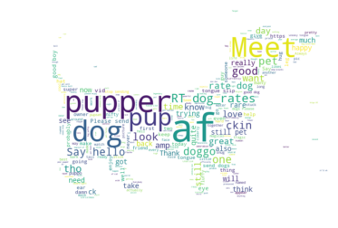

```python
# Code from https://amueller.github.io/word_cloud/auto_examples/masked.html
# Slightly modified to be applied to my data
from PIL import Image
import numpy as np
import matplotlib.pyplot as plt

from wordcloud import WordCloud, STOPWORDS

# All tweeted texts combined into a single text
texts = tw_clean.text.str.cat(sep=' ')
texts = texts.replace('https://t.co/','')

# Read the mask image
# (Taken from http://www.stencilry.org/stencils/animals/dog/dog+3.gif )
dog_mask = np.array(Image.open("dog_mask.png"))

stopwords = set(STOPWORDS)
stopwords.add("@dog_rates")

wc = WordCloud(background_color="white", max_words=2000, mask=dog_mask,
               stopwords=stopwords)

# Generate word cloud
wc.generate(texts)

# Store to file
wc.to_file("dog_wordcloud.png")

# Show
plt.imshow(wc, interpolation='bilinear')
plt.axis("off")
plt.figure()
plt.show()
#plt.imshow(dog_mask, cmap=plt.cm.gray, interpolation='bilinear')
#plt.axis("off")
```

### Most popular breeds

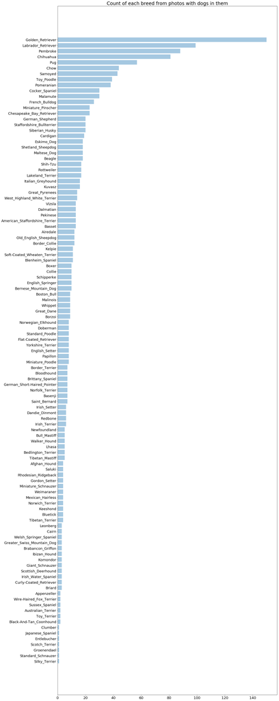

```python
counts = tw_clean.p1.value_counts()

names = list(counts.axes[0])
names.reverse()
values = list(counts.get_values())
values.reverse()

fig = plt.figure(figsize=(20,50))
ax = fig.add_subplot(111)
yvals = range(len(names))
ax.barh(yvals, values, align='center', alpha=0.4)
ax.tick_params(axis='both', labelsize=18)
plt.yticks(yvals,names)
plt.title('Count of each breed from photos with dogs in them', fontsize = 24)
plt.tight_layout()

plt.savefig('breeds_counts.png', bbox_inches='tight')
plt.show()
```

### Retweets by breed

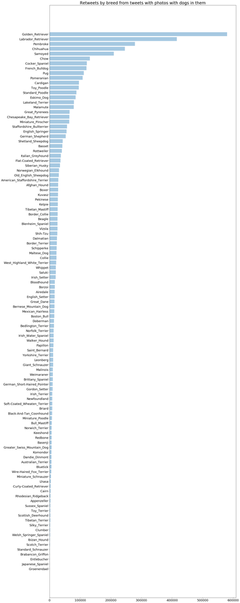

```python
breed_rt = tw_clean.groupby('p1').agg({'retweet_count': sum})
breed_rt = breed_rt.retweet_count.sort_values(ascending=False)

names = list(breed_rt.axes[0])
names.reverse()
values = list(breed_rt.get_values())
values.reverse()

fig = plt.figure(figsize=(20,50))
ax = fig.add_subplot(111)
yvals = range(len(names))
ax.barh(yvals, values, align='center', alpha=0.4)
ax.tick_params(axis='both', labelsize=18)
plt.yticks(yvals,names)
plt.title('Retweets by breed from tweets with photos with dogs in them', fontsize = 24)
plt.tight_layout()

plt.savefig('breeds_retweets.png', bbox_inches='tight')
plt.show()
```

### Most popular stages

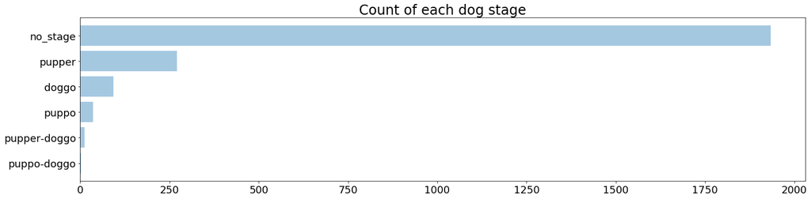

```python
counts = tw_clean.dog_stage.value_counts()

names = list(counts.axes[0])
names.reverse()
values = list(counts.get_values())
values.reverse()

fig = plt.figure(figsize=(20,5))
ax = fig.add_subplot(111)
yvals = range(len(names))
ax.barh(yvals, values, align='center', alpha=0.4)
ax.tick_params(axis='both', labelsize=18)
plt.yticks(yvals,names)
plt.title('Count of each dog stage', fontsize = 24)
plt.tight_layout()

plt.savefig('stages.png', bbox_inches='tight')
plt.show()
```

### Retweet counts by rating

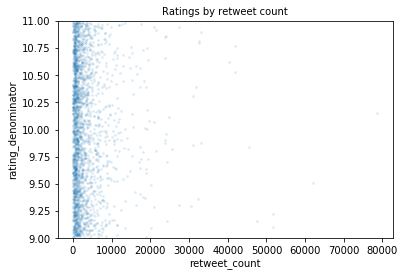

```python
# To add jitter to scatterplot
jitter = np.random.uniform(low = -.99, high = .99, size = len(tw_clean))
tw_jitter = tw_clean.copy()
tw_jitter.retweet_count = tw_jitter.retweet_count + jitter
tw_jitter.rating_denominator = tw_jitter.rating_denominator + jitter
fig = tw_jitter.plot.scatter('retweet_count', 'rating_denominator',alpha=0.1, s=3)
fig.axes.set_ylim(9,11)
plt.title('Ratings by retweet count', fontsize = 10)

plt.savefig('ratings_retweets.png', bbox_inches='tight')
plt.show()
```

### First insights

#### Breed popularity

The top five most popular breeds are Golden Retriever, Labrador Retriever, Pembroke, Chihuahua, and Pug. The top one, Golden Retriever, appears almost double and three times more than fourth and fifth places.

Unsurprisingly, the breeds whose photos and tweet were most retweeted were also, in order, Golden Retriever, Labrador Retriever, Pembroke, Chihuahua, but in fifth place is Samoyed (seventh in number of appearances). Pugs are popular but do not get as retweeted.

Overall, however, breeds that have high counts are also generally highly retweeted.

#### Stage popularity

The most common stage mentioned is “pupper”, three times more than the second most mentioned stage “doggo”, in turn twice as frequent as the least common stage “puppo”.

Double stages, or two dogs, are much less common. Consistent with the single stage popularity ranking, of the combinations, “pupper-doggo” is the most common. Interestingly, there are no “pupper-puppo” duos.